# Module 11

## Type II Error

By reducing the *α* level we use as our criterion for statistical significance, we can reduce the chance of committing a Type I error (incorrectly rejecting the null), but doing so directly increases our chance of committing a Type II error (incorrectly *failing* to reject the null). The shaded area in this figure below, *β*, is the probability of incorrectly failing to reject the null...

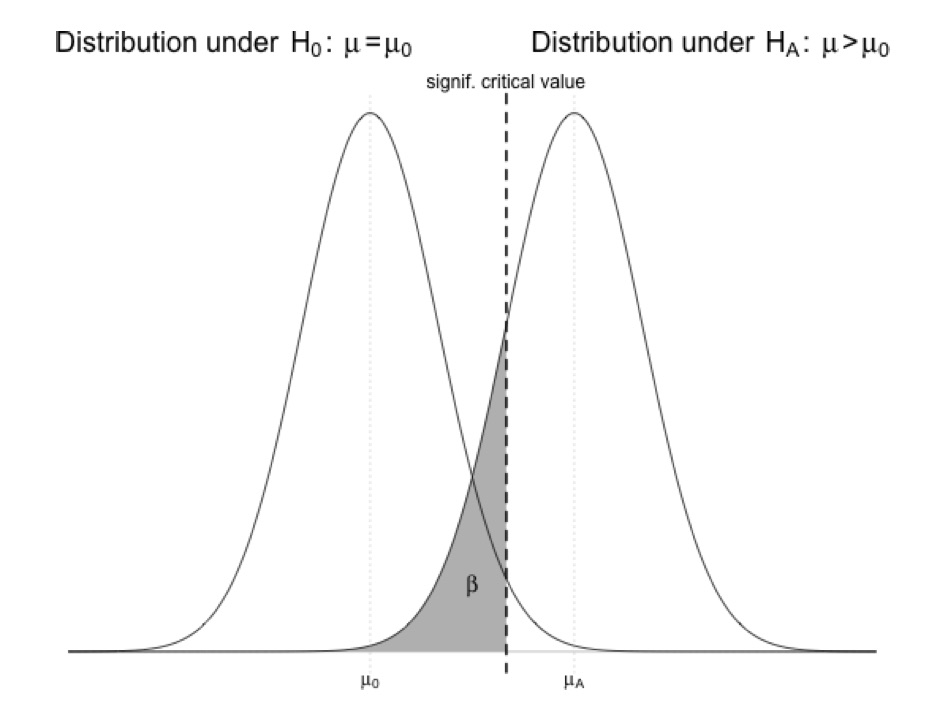

In practice, we cannot usually calculate *β* because of the need to know where the true distribution is really centered (i.e., we need to know the value of *μ*<sub>*A*</sub>, which is often unknown). However, we can explore via simulation what *β* is expected to look like under different alternative hypotheses (e.g., under different *μ*<sub>*A*</sub>) and under different sample sizes and *α* levels.

Let's do this using the simulation approach we developed above. Again, we will write some code to simulate a bunch of random datasets, this time drawn from a normal distribution associated with a particular alternative hypothesis, *H*<sub>*A*</sub>, that we define... i.e., where we specify *μ*<sub>*A*</sub>. We then calculate a Z (or T) statistic based on each sample dataset relative to *μ*<sub>0</sub>, the expected mean under *H*<sub>0</sub>, and determine the associated p value for each one. Based on this, we can calculate the Type II error rate... the proportion of times that, based on our samples, we would conclude that it was drawn from the *H*<sub>0</sub> distribution rather than the *H*<sub>*A*</sub> distribution that we set to be true. Note that, as above, we can use the "t" family of functions in lieu of the "norm" family.

```r
> typeII <- function(mu0, muA, sigma, n, alternative = "two.tailed", alpha = 0.05,
+     k = 1000) {
+     p <- rep(NA, k)  # sets up a vector of empty p values
+     for (i in 1:k) {
+         x <- rnorm(n = n, mean = muA, sd = sigma)  # draw from Ha
+         m <- mean(x)
+         s <- sd(x)
+         z <- (m - mu0)/(s/sqrt(n))  # calculates the Z statistic for the sample drawn from Ha relative to the null distribution
+         if (alternative == "less") {
+             p[i] <- pnorm(z, lower.tail = TRUE)  # calculates the associated p value
+             hyp <- "muA < mu0"
+         }
+         if (alternative == "greater") {
+             p[i] <- pnorm(z, lower.tail = FALSE)
+             hyp <- "muA > mu0"
+         }
+         if (alternative == "two.tailed") {
+             if (z > 0) {
+                 p[i] <- 2 * pnorm(z, lower.tail = FALSE)
+             }
+             if (z < 0) {
+                 p[i] <- 2 * pnorm(z, lower.tail = TRUE)
+             }
+             hyp <- "muA ≠ mu0"
+         }
+     }
+
+     curve(dnorm(x, mu0, sigma/sqrt(n)), mu0 - 4 * sigma/sqrt(n), mu0 + 4 * sigma/sqrt(n),
+         main = paste("Sampling Distributions Under the Null (red)\nand Alternative Hypotheses (blue)\nType II error rate from simulation = ",
+             length(p[p >= alpha])/k, sep = ""), xlab = "x", ylab = "Pr(x)",
+         col = "red", xlim = c(min(c(mu0 - 4 * sigma/sqrt(n), muA - 4 * sigma/sqrt(n))),
+             max(c(mu0 + 4 * sigma/sqrt(n), muA + 4 * sigma/sqrt(n)))), ylim = c(0,
+             max(c(dnorm(mu0, mu0, sigma/sqrt(n))), dnorm(muA, muA, sigma/sqrt(n)))))
+
+     curve(dnorm(x, muA, sigma/sqrt(n)), muA - 4 * sigma/sqrt(n), muA + 4 * sigma/sqrt(n),
+         col = "blue", add = TRUE)
+     abline(h = 0)
+
+     if (alternative == "less") {
+         polygon(cbind(c(mu0 - qnorm(1 - alpha) * sigma/sqrt(n), seq(from = mu0 -
+             qnorm(1 - alpha) * sigma/sqrt(n), to = muA + 4 * sigma/sqrt(n),
+             length.out = 100), muA + 4 * sigma/sqrt(n))), c(0, dnorm(seq(mu0 -
+             qnorm(1 - alpha) * sigma/sqrt(n), to = muA + 4 * sigma/sqrt(n),
+             length.out = 100), mean = muA, sd = sigma/sqrt(n)), 0), border = "black",
+             col = "grey")
+         abline(v = mu0 - qnorm(1 - alpha) * sigma/sqrt(n), col = "black", lty = 3,
+             lwd = 2)
+     }
+
+     if (alternative == "greater") {
+         polygon(cbind(c(muA - 4 * sigma/sqrt(n), seq(from = muA - 4 * sigma/sqrt(n),
+             to = mu0 + qnorm(1 - alpha) * sigma/sqrt(n), length.out = 100),
+             mu0 + qnorm(1 - alpha) * sigma/sqrt(n))), c(0, dnorm(seq(from = muA -
+             4 * sigma/sqrt(n), to = mu0 + qnorm(1 - alpha) * sigma/sqrt(n),
+             length.out = 100), mean = muA, sd = sigma/sqrt(n)), 0), border = "black",
+             col = "grey")
+         abline(v = mu0 + qnorm(1 - alpha) * sigma/sqrt(n), col = "black", lty = 3,
+             lwd = 2)
+     }
+
+     if (alternative == "two.tailed") {
+         abline(v = mu0 - qnorm(1 - alpha/2) * sigma/sqrt(n), col = "black",
+             lty = 3, lwd = 2)
+         abline(v = mu0 + qnorm(1 - alpha/2) * sigma/sqrt(n), col = "black",
+             lty = 3, lwd = 2)
+
+         if (z > 0) {
+             # greater
+             polygon(cbind(c(muA - 4 * sigma/sqrt(n), seq(from = muA - 4 * sigma/sqrt(n),
+                 to = mu0 + qnorm(1 - alpha/2) * sigma/sqrt(n), length.out = 100),
+                 mu0 + qnorm(1 - alpha/2) * sigma/sqrt(n))), c(0, dnorm(seq(from = muA -
+                 4 * sigma/sqrt(n), to = mu0 + qnorm(1 - alpha/2) * sigma/sqrt(n),
+                 length.out = 100), mean = muA, sd = sigma/sqrt(n)), 0), border = "black",
+                 col = "grey")
+         }
+
+         # less
+         if (z < 0) {
+             polygon(cbind(c(mu0 - qnorm(1 - alpha/2) * sigma/sqrt(n), seq(from = mu0 -
+                 qnorm(1 - alpha/2) * sigma/sqrt(n), to = muA + 4 * sigma/sqrt(n),
+                 length.out = 100), muA + 4 * sigma/sqrt(n))), c(0, dnorm(seq(mu0 -
+                 qnorm(1 - alpha/2) * sigma/sqrt(n), to = muA + 4 * sigma/sqrt(n),
+                 length.out = 100), mean = muA, sd = sigma/sqrt(n)), 0), border = "black",
+                 col = "grey")
+         }
+     }
+
+     return(length(p[p >= alpha])/k)
+ }
```

#### CHALLENGE:

Explore this function using different values of *μ*<sub>0</sub>, *σ*, *n*, and different types of one- and two-tailed tests.

```r
> eII <- typeII(mu0 = 2, muA = 4, sigma = 3, n = 6, alternative = "greater")  # Ha > H0
```

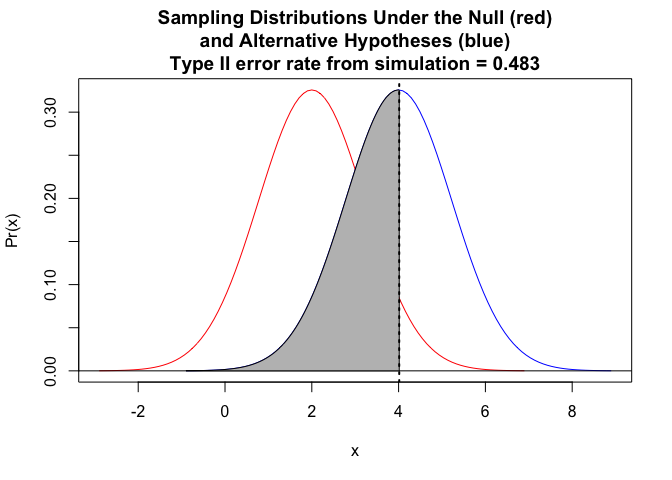

```r
> eII <- typeII(mu0 = 5, muA = 2, sigma = 4, n = 18, alternative = "less")  # Ha < H0
```

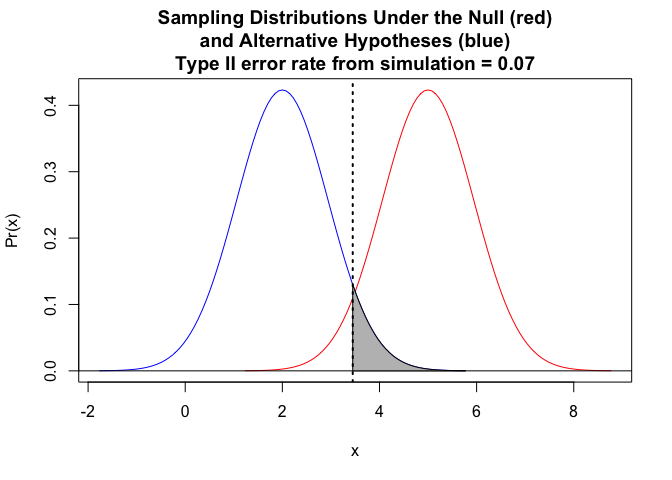

```r
> eII <- typeII(mu0 = 5, muA = 7, sigma = 2, n = 15, alternative = "two.tailed")  # Ha ≠ H0
```

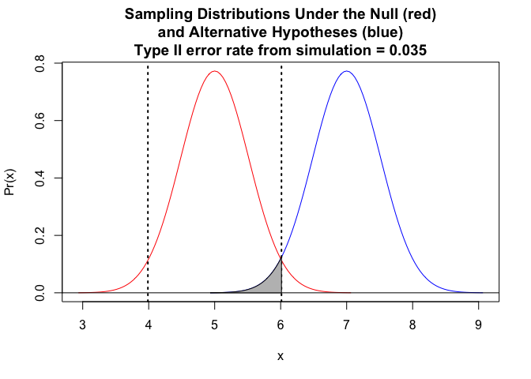

## Power

Power is the **probability of correctly rejecting a null hypothesis that is untrue**. For a test that has a Type II error rate of *β*, the statistical power is defined, simply, as 1 − *β*. Power values of 0.8 or greater are conventionally considered to be high. Power for any given test depends on the difference between *μ* between groups/treatments, *α*, *n*, and *σ*.

## Effect Size

Generally speaking, an effect size is a quantitative measure of the strength of a phenomenon. Here, we are interested in comparing two sample means, and the most common way to describe the effect size is as a **standardized difference** between the means of the groups being compared. In this case, we divide the difference between the means by the standard deviation: |(*μ*<sub>0</sub> - *μ*<sub>*A*</sub>)|/*σ*. This results in a scaleless measure. Conventionally, effect sizes of 0.2 or less are considered to be low and of 0.8 or greater are considered to be high.

## Graphical Depiction of Power and Effect Size

The code below lets you explore power and effect size interactively. You can use the sliders to set *μ*<sub>0</sub> and *μ*<sub>*A*</sub> for a one-sample test (or, alternatively, think about these as *μ*<sub>1</sub> and *μ*<sub>2</sub> for a two-sample test), *σ*, *α*, *n*, and you can choose whether you are testing a one-sided hypothesis of *μ*<sub>*A*</sub> being "greater" or "less" than *μ*<sub>*A*</sub> or are testing the two-sided hypothesis that *μ*<sub>*A*</sub> ≠ *μ*<sub>0</sub> ("two.tailed"). The graph will output *P**o**w**e**r* and *E**f**f**e**c**t**S**i**z**e*.

```r
> library(ggplot2)
> library(manipulate)
> power.plot <- function(sigma, muA, mu0, n, alpha, alternative = "two.tailed") {
+     pow <- 0
+     z <- (muA - mu0)/(sigma/sqrt(n))
+     g <- ggplot(data.frame(mu = c(min(mu0 - 4 * sigma/sqrt(n), muA - 4 * sigma/sqrt(n)),
+         max(mu0 + 4 * sigma/sqrt(n), muA + 4 * sigma/sqrt(n)))), aes(x = mu)) +
+         ggtitle("Explore Power for Z Test")
+     g <- g + ylim(c(0, max(dnorm(mu0, mu0, sigma/sqrt(n)) + 0.1, dnorm(muA,
+         muA, sigma/sqrt(n)) + 0.1)))
+     g <- g + stat_function(fun = dnorm, geom = "line", args = list(mean = mu0,
+         sd = sigma/sqrt(n)), size = 1, col = "red", show.legend = TRUE)
+     g <- g + stat_function(fun = dnorm, geom = "line", args = list(mean = muA,
+         sd = sigma/sqrt(n)), size = 1, col = "blue", show.legend = TRUE)
+
+     if (alternative == "greater") {
+         if (z > 0) {
+             xcrit = mu0 + qnorm(1 - alpha) * sigma/sqrt(n)
+             g <- g + geom_segment(x = xcrit, y = 0, xend = xcrit, yend = max(dnorm(mu0,
+                 mu0, sigma/sqrt(n)) + 0.025, dnorm(muA, muA, sigma/sqrt(n)) +
+                 0.025), size = 0.5, linetype = 3)
+             g <- g + geom_polygon(data = data.frame(cbind(x = c(xcrit, seq(from = xcrit,
+                 to = muA + 4 * sigma/sqrt(n), length.out = 100), muA + 4 * sigma/sqrt(n)),
+                 y = c(0, dnorm(seq(from = xcrit, to = muA + 4 * sigma/sqrt(n),
+                   length.out = 100), mean = muA, sd = sigma/sqrt(n)), 0))),
+                 aes(x = x, y = y), fill = "blue", alpha = 0.5)
+             pow <- pnorm(muA + 4 * sigma/sqrt(n), muA, sigma/sqrt(n)) - pnorm(xcrit,
+                 muA, sigma/sqrt(n))
+         }
+     }
+     if (alternative == "less") {
+         if (z < 0) {
+             xcrit = mu0 - qnorm(1 - alpha) * sigma/sqrt(n)
+             g <- g + geom_segment(x = xcrit, y = 0, xend = xcrit, yend = max(dnorm(mu0,
+                 mu0, sigma/sqrt(n)) + 0.025, dnorm(muA, muA, sigma/sqrt(n)) +
+                 0.025), size = 0.5, linetype = 3)
+             g <- g + geom_polygon(data = data.frame(cbind(x = c(muA - 4 * sigma/sqrt(n),
+                 seq(from = muA - 4 * sigma/sqrt(n), to = xcrit, length.out = 100),
+                 xcrit), y = c(0, dnorm(seq(from = muA - 4 * sigma/sqrt(n), to = xcrit,
+                 length.out = 100), mean = muA, sd = sigma/sqrt(n)), 0))), aes(x = x,
+                 y = y), fill = "blue", alpha = 0.5)
+             pow <- pnorm(xcrit, muA, sigma/sqrt(n)) - pnorm(muA - 4 * sigma/sqrt(n),
+                 muA, sigma/sqrt(n))
+         }
+     }
+     if (alternative == "two.tailed") {
+         if (z > 0) {
+             xcrit = mu0 + qnorm(1 - alpha/2) * sigma/sqrt(n)
+             g <- g + geom_segment(x = xcrit, y = 0, xend = xcrit, yend = max(dnorm(mu0,
+                 mu0, sigma/sqrt(n)) + 0.025, dnorm(muA, muA, sigma/sqrt(n)) +
+                 0.025), size = 0.5, linetype = 3)
+             g <- g + geom_polygon(data = data.frame(cbind(x = c(xcrit, seq(from = xcrit,
+                 to = muA + 4 * sigma/sqrt(n), length.out = 100), muA + 4 * sigma/sqrt(n)),
+                 y = c(0, dnorm(seq(from = xcrit, to = muA + 4 * sigma/sqrt(n),
+                   length.out = 100), mean = muA, sd = sigma/sqrt(n)), 0))),
+                 aes(x = x, y = y), fill = "blue", alpha = 0.5)
+             pow <- pnorm(muA + 4 * sigma/sqrt(n), muA, sigma/sqrt(n)) - pnorm(xcrit,
+                 muA, sigma/sqrt(n))
+         }
+         if (z < 0) {
+             xcrit = mu0 - qnorm(1 - alpha/2) * sigma/sqrt(n)
+             g <- g + geom_segment(x = xcrit, y = 0, xend = xcrit, yend = max(dnorm(mu0,
+                 mu0, sigma/sqrt(n)) + 0.025, dnorm(muA, muA, sigma/sqrt(n)) +
+                 0.025), size = 0.5, linetype = 3)
+             g <- g + geom_polygon(data = data.frame(cbind(x = c(muA - 4 * sigma/sqrt(n),
+                 seq(from = muA - 4 * sigma/sqrt(n), to = xcrit, length.out = 100),
+                 xcrit), y = c(0, dnorm(seq(from = muA - 4 * sigma/sqrt(n), to = xcrit,
+                 length.out = 100), mean = muA, sd = sigma/sqrt(n)), 0))), aes(x = x,
+                 y = y), fill = "blue", alpha = 0.5)
+             pow <- pnorm(xcrit, muA, sigma/sqrt(n)) - pnorm(muA - 4 * sigma/sqrt(n),
+                 muA, sigma/sqrt(n))
+         }
+     }
+     g <- g + annotate("text", x = max(mu0, muA) + 2 * sigma/sqrt(n), y = max(dnorm(mu0,
+         mu0, sigma/sqrt(n)) + 0.075, dnorm(muA, muA, sigma/sqrt(n)) + 0.075),
+         label = paste("Effect Size = ", round((muA - mu0)/sigma, digits = 3),
+             "\nPower = ", round(pow, digits = 3), sep = ""))
+     g <- g + annotate("text", x = min(mu0, muA) - 2 * sigma/sqrt(n), y = max(dnorm(mu0,
+         mu0, sigma/sqrt(n)) + 0.075, dnorm(muA, muA, sigma/sqrt(n)) + 0.075),
+         label = "Red = mu0\nBlue = muA")
+     g
+ }
```

```r
> manipulate(power.plot(sigma, muA, mu0, n, alpha, alternative), sigma = slider(1,
+     10, step = 1, initial = 4), muA = slider(-10, 10, step = 1, initial = 2),
+     mu0 = slider(-10, 10, step = 1, initial = 0), n = slider(1, 50, step = 1,
+         initial = 16), alpha = slider(0.01, 0.1, step = 0.01, initial = 0.05),
+     alternative = picker("two.tailed", "greater", "less"))
```

In most cases, since we are dealing with limited samples from a population, we will want to use the t rather than the normal distibution as the basis for making our power evaluations. The `power.t.test()` function lets us easily implement power calculations based on the t distribution, and the results of using it should be very similar to those we found above by simulation. The `power.t.test()` function takes as possible arguments the sample size (*n*), the difference (delta, *δ*) between group means, the standard deviation of the data = sigma (*σ*), the sig.level = alpha (*α*), the test type ("two.sample", "one.sample", or "paired"), the alternative test to run ("two.sided", "one sidedd") and the power. Power, *n*, or the difference between means is left as null and the other arguments are specified. The function then calculate the missing argument.

#### CHALLENGE:

Using the code below, which graphs the Type II error rate (*β*) and Power (1 − *β*) for T tests (using the `power.t.test()` function), explore the effects of changing *α*, within sample variability (*σ*), and the difference between sample means (i.e., *μ*<sub>0</sub> and *μ*<sub>*A*</sub> for a one sample test (or, equivalently, *μ*<sub>1</sub> and *μ*<sub>2</sub> for a two sample test). The plot shows the effect size, given the difference between the means, (i.e., |(*μ*<sub>0</sub> − *μ*<sub>*A*</sub>)|/*σ*) and marks the sample size (*n*) needed to achieve a power of 0.8.

```r
> library(ggplot2)
> library(manipulate)
> power.test <- function(mu0, muA, sigma, alpha = 0.05, type, alternative) {
+     p <- 0
+     for (i in 2:200) {
+         x <- power.t.test(n = i, delta = abs(muA - mu0), sd = sigma, sig.level = alpha,
+             power = NULL, type = type, alternative = alternative)
+         p <- c(p, x$power)
+     }
+     d <- data.frame(cbind(1:200, p, 1 - p))
+     critn <- 0
+     for (i in 1:199) {
+         if (p[i] < 0.8 && p[i + 1] >= 0.8) {
+             critn <- i + 1
+         } else {
+             critn <- critn
+         }
+     }
+     names(d) <- c("n", "power", "beta")
+     g <- ggplot(data = d) + xlab("sample size n") + ylab("Type II Error Rate, Beta  (Red)\nand\nPower, 1-Beta (Blue)") +
+         ggtitle("Power for T Tests\n(assuming equal n and variance across the two groups)") +
+         ylim(0, 1) + geom_point(aes(x = n, y = power), colour = "blue", alpha = 1/2) +
+         geom_line(aes(x = n, y = power), colour = "blue", alpha = 1/2) + geom_line(aes(x = n,
+         y = 0.8), colour = "red", lty = 3) + geom_point(aes(x = n, y = beta),
+         colour = "red", alpha = 1/2) + geom_line(aes(x = n, y = beta), colour = "red",
+         alpha = 1/2) + geom_linerange(aes(x = critn, ymin = 0, ymax = 0.8),
+         colour = "blue", alpha = 1/4) + annotate("text", x = 150, y = 0.5, label = paste("Effect Size = ",
+         round(abs(mu0 - muA)/sigma, digits = 3), "\nCritical n = ", critn, sep = ""))
+     print(g)
+ }
```

```r
> manipulate(power.test(mu0, muA, sigma, alpha, type, alternative), mu0 = slider(-10,
+     10, initial = 3, step = 1), muA = slider(-10, 10, initial = 0, step = 1),
+     sigma = slider(1, 10, initial = 3, step = 1), alpha = slider(0.01, 0.1,
+         initial = 0.05, step = 0.01), alternative = picker("two.sided", "one.sided"),
+     type = picker("two.sample", "one.sample", "paired"))
```